# FZJ Data Analysis Timepoints

Elise

2024-06-09

Set the right working directory.

```r
rm(list = ls())

setwd("C:/Users/elise/Documents/Mémoire/Main/Data/Templates/FZJ")
platform <- "FZJ"
```

# Data importation

Reimport the data sets extracted from the Data Preparation and Data Analysis R Markdown.

```r
list.files()
```

```
## [1] "endpoint.txt"     "plant_info.txt"   "S_timeseries.txt" "T_timeseries.txt"
## [5] "timeseries.txt"
```

```r
plant_info <- read.table("plant_info.txt", header = TRUE, sep = "\t")
endpoint <- read.table("endpoint.txt", header = TRUE, sep = "\t")
timeseries <- read.table("timeseries.txt", header = TRUE, sep = "\t")

# plant_info
plant_info <- lapply(plant_info, factor)

# endpoint
matching_cols <- intersect(names(endpoint), names(plant_info))
endpoint[, matching_cols] <- lapply(endpoint[, matching_cols], factor)
endpoint$Date <- date(endpoint$Date)
endpoint$Timestamp <- NA

# timeseries
matching_cols <- intersect(names(timeseries), names(plant_info))
timeseries[, matching_cols] <- lapply(timeseries[, matching_cols], factor)
timeseries$Date <- date(timeseries$Date)
timeseries$Timestamp <- NA

platform <- "FZJ"

# endpoint
df <- endpoint[,colSums(is.na(endpoint))<nrow(endpoint)]
genotype_index <- which(colnames(df) == "Genotype")
variables <- colnames(df[, c(3:(genotype_index - 1))]) # We remove the two first columns that are "Unit.ID" and "Date"

# timeseries
variables_t <- c("Manual_Plant_height_cm")


print(paste(platform, ": The variables for timeseries are", paste(variables_t, collapse = ", "), sep = " "))
```

```
## [1] "FZJ : The variables for timeseries are Manual_Plant_height_cm"
```

```r
endpoint$Plant_type <- substr(endpoint$Genotype, nchar(as.character(endpoint$Genotype)), nchar(as.character(endpoint$Genotype)))
timeseries$Plant_type <- substr(timeseries$Genotype, nchar(as.character(timeseries$Genotype)), nchar(as.character(timeseries$Genotype)))
```

Get the cleaned endpoint data

```r
endpoint_clean <- endpoint
# Run the function on the dataset for all the variables
endpoint_clean <- detect_replace_outliers_by_genotype(endpoint_clean)



# We add a Plant_type variable that is H or L, with T being L
timeseries$Plant_type <- substr(timeseries$Genotype, nchar(as.character(timeseries$Genotype)), nchar(as.character(timeseries$Genotype)))

timeseries$Plant_type <- ifelse(timeseries$Plant_type %in% c("T", "L"), "Line",
                                  ifelse(timeseries$Plant_type == "H", "Hybrid", timeseries$Plant_type))
```

# Time point objects

Generation of the timePoints objects using the function “createTimePoints”.

```r
timePoint_endpoint <- createTimePoints(dat = endpoint,
                                      experimentName = "EPPN2020_FZJ",
                                      genotype = "Genotype",
                                      timePoint = "Date",
                                      plotId = "Unit.ID",
                                      rowNum = "Row",
                                      colNum = "Column",
                                      repId = "Replication")

timePoint_endpoint_clean <- createTimePoints(dat = endpoint_clean,
                                      experimentName = "EPPN2020_FZJ",
                                      genotype = "Genotype",
                                      timePoint = "Date",
                                      plotId = "Unit.ID",
                                      rowNum = "Row",
                                      colNum = "Column",
                                      repId = "Replication")

timePoint_S <- createTimePoints(dat = timeseries,
                              experimentName = "EPPN2020_FZJ",
                              genotype = "Genotype",
                              timePoint = "Date",
                              plotId = "Unit.ID",
                              rowNum = "Row",
                              colNum = "Column",
                              repId = "Replication",
                              addCheck = TRUE,
                              checkGenotypes = "EPPN20_T")
```

## Gentoypic layout

Check the layout of the platforms’ genotypes.

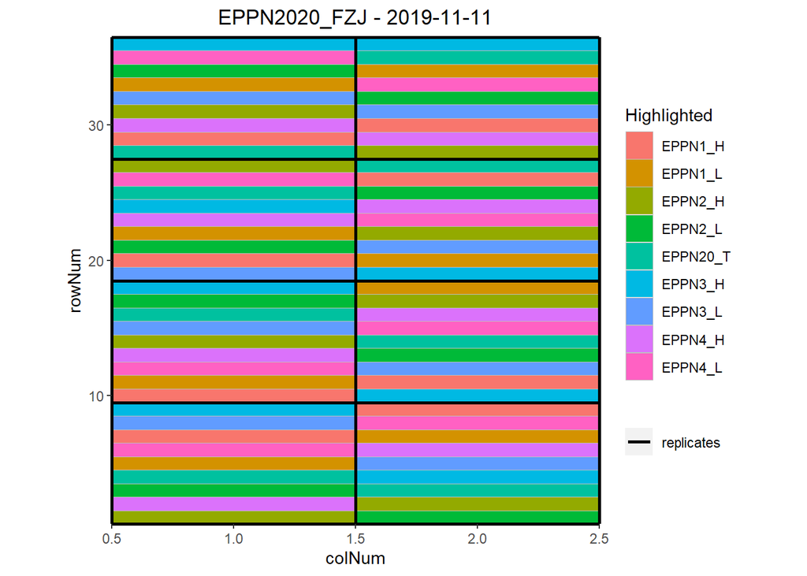

```r
genotypes_list <- as.character(unique(endpoint$Genotype))

plot(timePoint_endpoint,
     plotType = "layout",
     highlight =  genotypes_list,
     showGeno = FALSE)
```

## 1. endpoint

### Comparisons between raw and cleaned data

#### View timePoint object.

```r
summary(timePoint_endpoint)
```

```
## timePoint_endpoint contains data for experiment EPPN2020_FZJ.
##
## It contains 1 time points.
## First time point: 2019-11-11
## Last time point: 2019-11-11
##
## No check genotypes are defined.
```

```r
getTimePoints(timePoint_endpoint)
```

```
##   timeNumber  timePoint
## 1          1 2019-11-11
```

#### Count the number of observations per trait.

```r
traits <- variables

for (trait_name in traits) {
  print(paste("How many data observations for", trait_name))
  num_observations <- countValid(timePoint_endpoint, trait_name)
  print(num_observations)
}
```

```
## [1] "How many data observations for DW_shoot_g"
## 2019-11-11
##         71
## [1] "How many data observations for FW_shoot_g"
## 2019-11-11
##         69
## [1] "How many data observations for DW_root_g"
## 2019-11-11
##         72
## [1] "How many data observations for Root_length_cm"
## 2019-11-11
##         72
## [1] "How many data observations for Root_number"
## 2019-11-11
##         67
## [1] "How many data observations for Root_angle"
## 2019-11-11
##         42
```

```r
for (trait_name in traits) {
  print(paste("How many cleaned data observations for", trait_name))
  num_observations <- countValid(timePoint_endpoint_clean, trait_name)
  print(num_observations)
}
```

```
## [1] "How many cleaned data observations for DW_shoot_g"
## 2019-11-11
##         65
## [1] "How many cleaned data observations for FW_shoot_g"
## 2019-11-11
##         61
## [1] "How many cleaned data observations for DW_root_g"
## 2019-11-11
##         69
## [1] "How many cleaned data observations for Root_length_cm"
## 2019-11-11
##         71
## [1] "How many cleaned data observations for Root_number"
## 2019-11-11
##         63
## [1] "How many cleaned data observations for Root_angle"
## 2019-11-11
##         40
```

#### Check the heatmap of the data at harvest

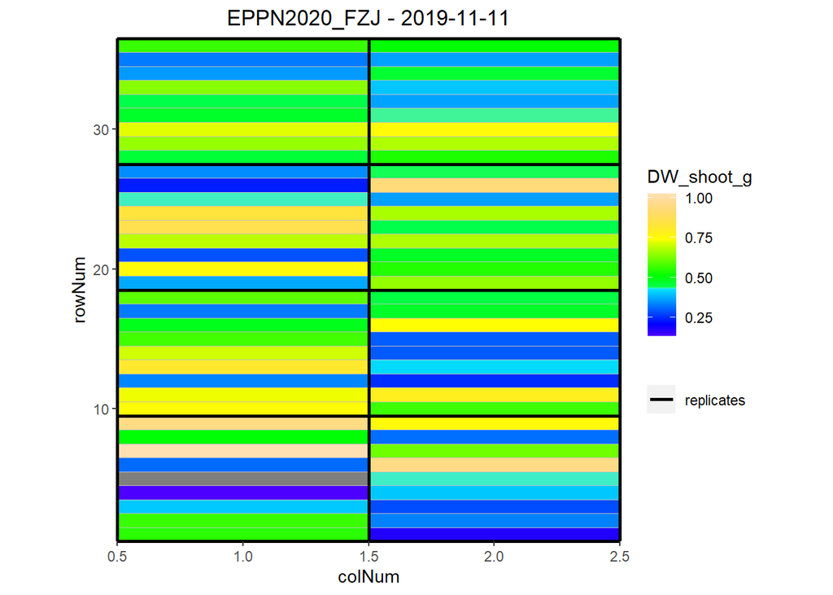

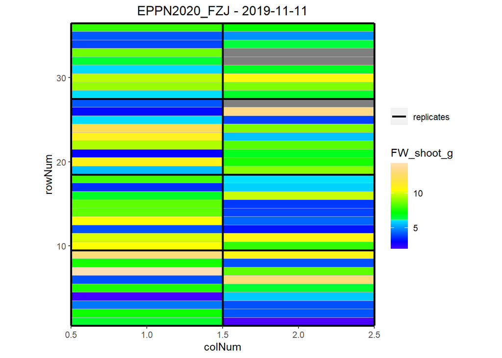

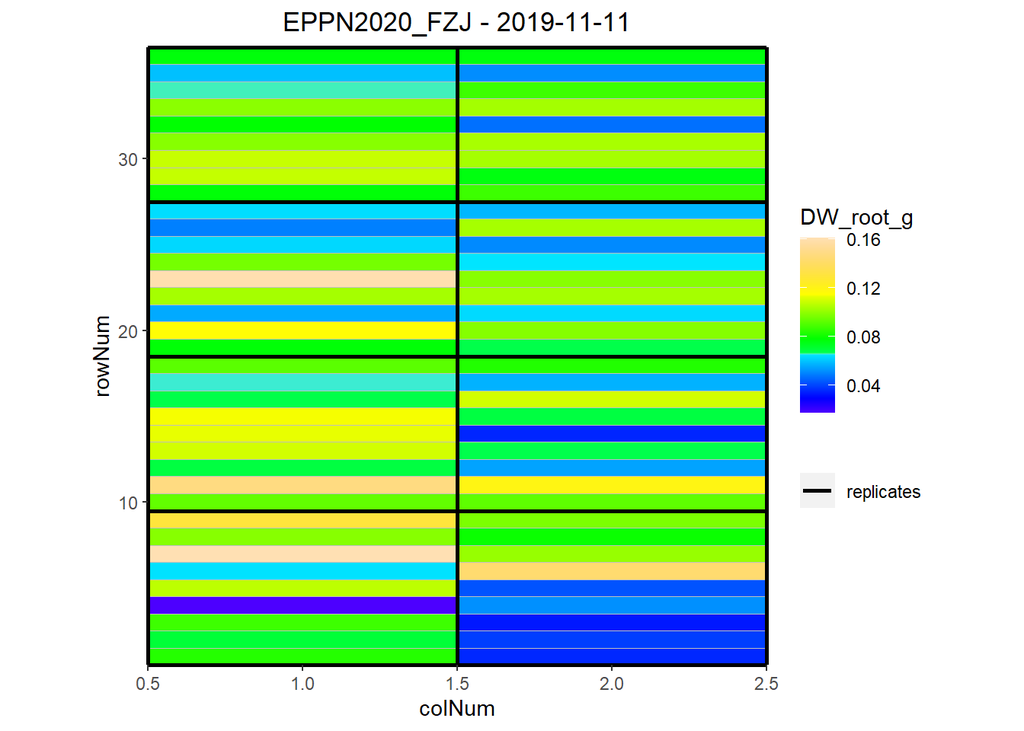

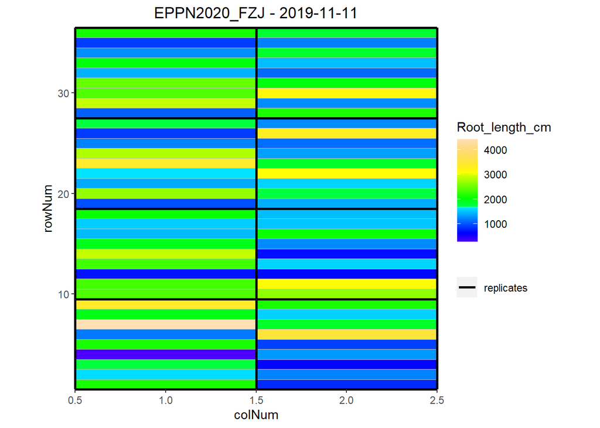

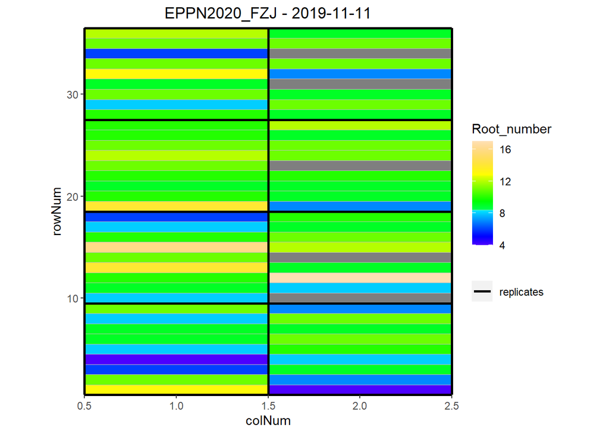

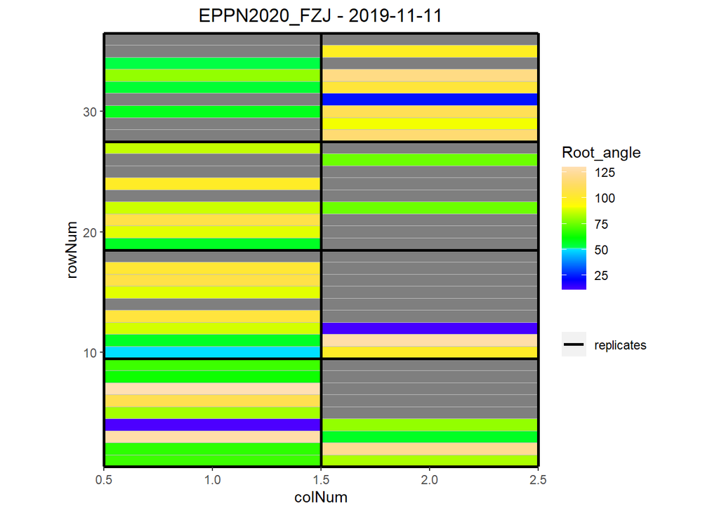

```r
for (trait_name in traits) {
  plot(timePoint_endpoint,
     plotType = "layout",
     timePoints = 1,
     traits = trait_name)
}
```

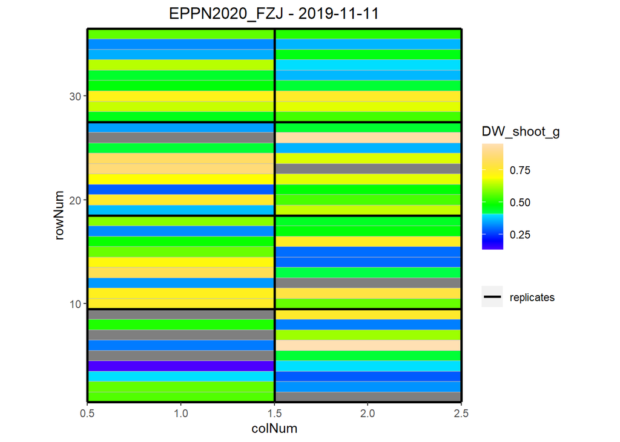

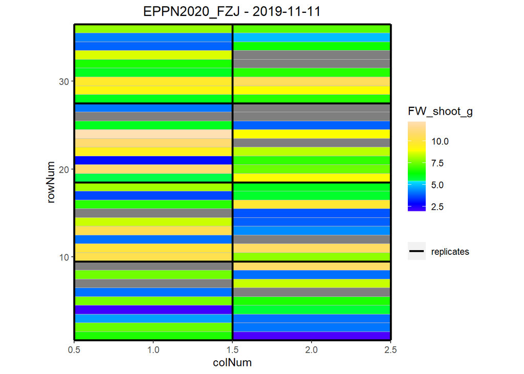

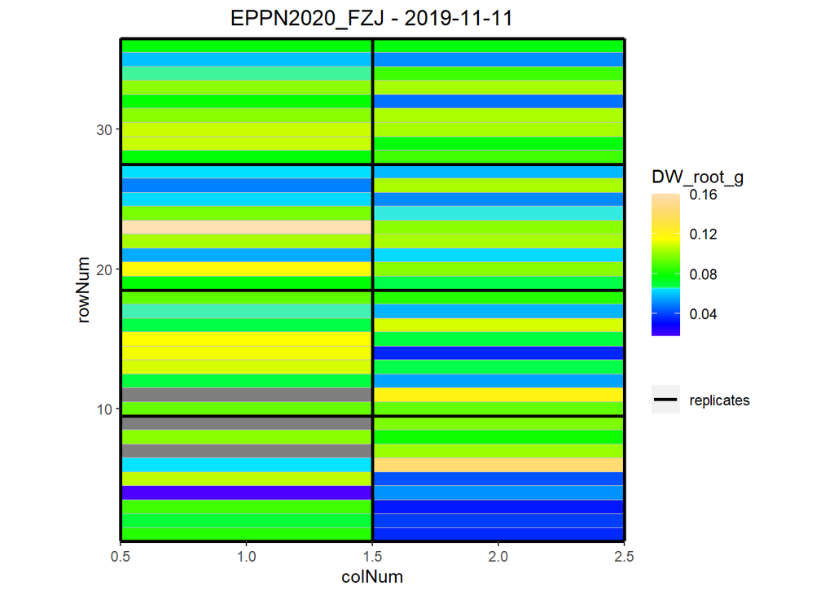

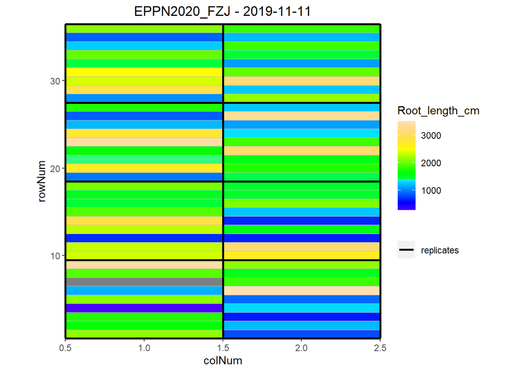

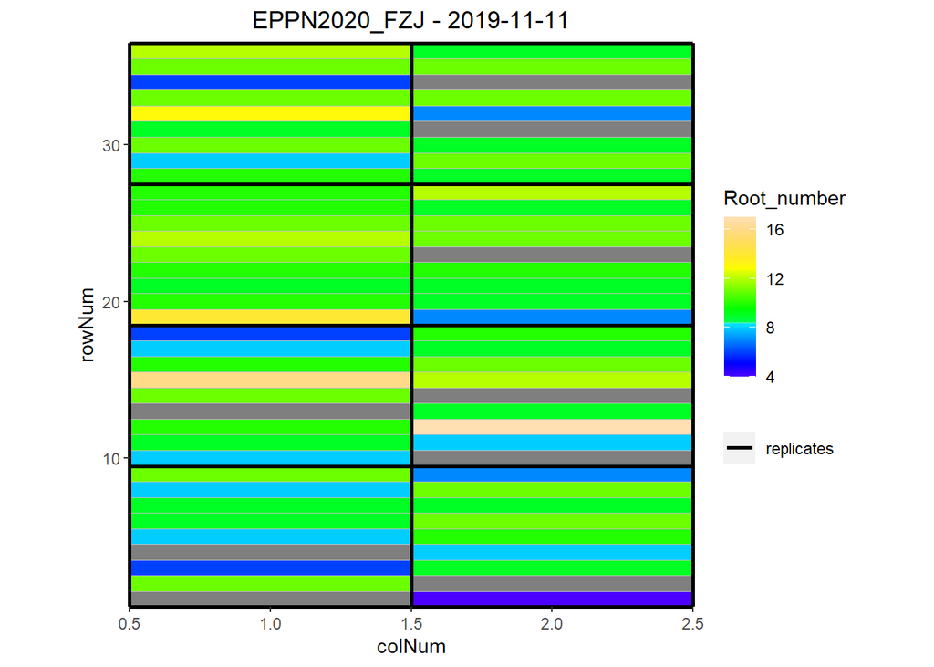

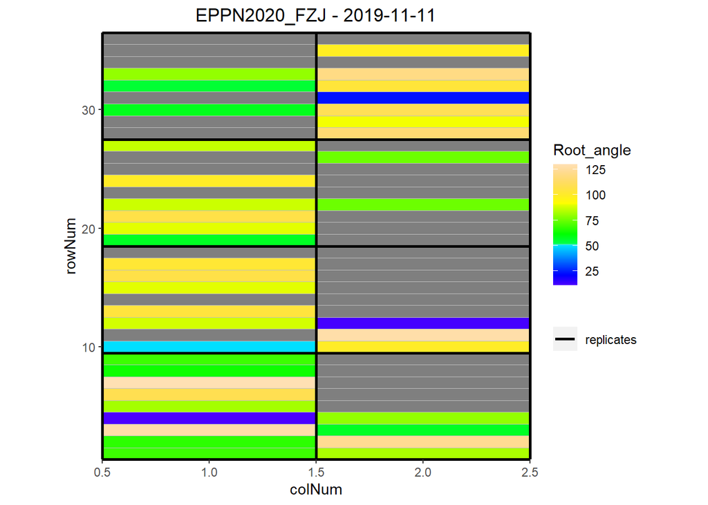

```r
for (trait_name in traits) {
  plot(timePoint_endpoint_clean,
     plotType = "layout",
     timePoints = 1,
     traits = trait_name)
}
```

## 2. timeseries

### Raw data

#### View timePoint object

```r
summary(timePoint_S)
```

```
## timePoint_S contains data for experiment EPPN2020_FZJ.
##
## It contains 5 time points.
## First time point: 2019-10-28
## Last time point: 2019-11-11
##
## The following genotypes are defined as check genotypes: EPPN20_T.
```

```r
getTimePoints(timePoint_S)
```

```
##   timeNumber  timePoint
## 1          1 2019-10-28
## 2          2 2019-10-31
## 3          3 2019-11-04
## 4          4 2019-11-07
## 5          5 2019-11-11
```

```r
num_timepoints <- getTimePoints(timePoint_S)
```

#### Count the number of observations per trait and time point

Height is computed for 6 platforms out of 9 and area for 4 out of 9.

```r
var_voulues <- c(variables_t)
traits <- var_voulues

for (trait_name in traits) {
  print(paste("How many observations for", trait_name))
  valid_count <- countValid(timePoint_S, trait_name)
  print(valid_count)
}
```

```
## [1] "How many observations for Manual_Plant_height_cm"
## 2019-10-28 2019-10-31 2019-11-04 2019-11-07 2019-11-11
##         72         72         72         72         70
```

#### Check the heatmap of the raw data per time point

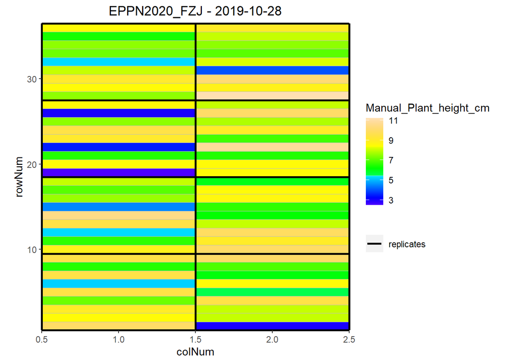

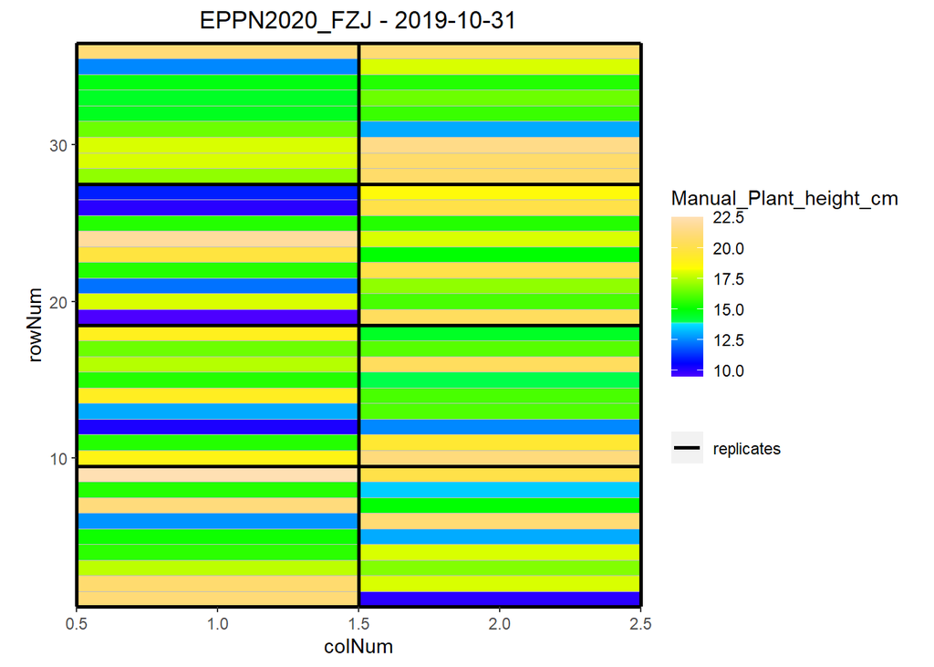

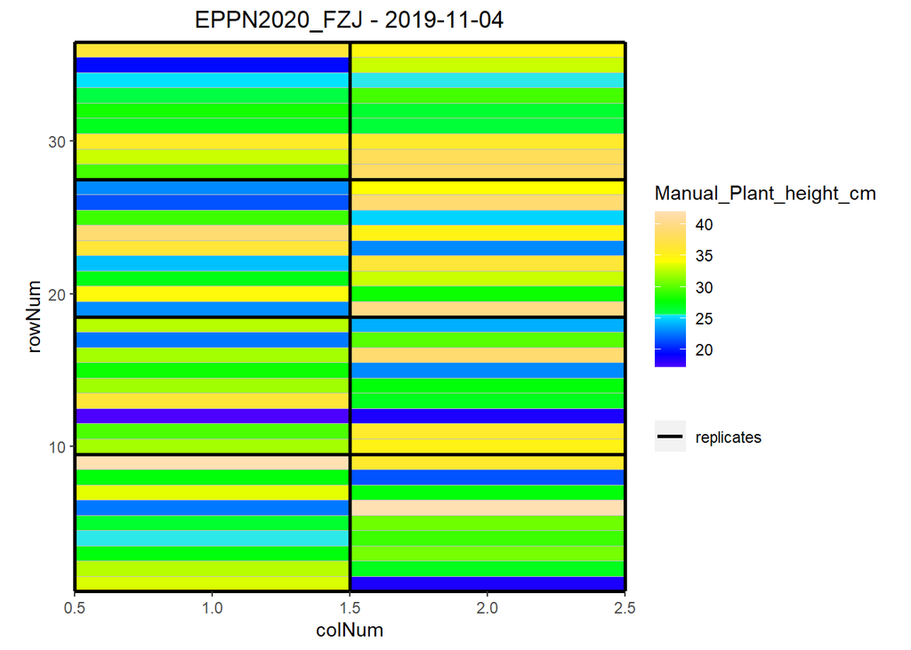

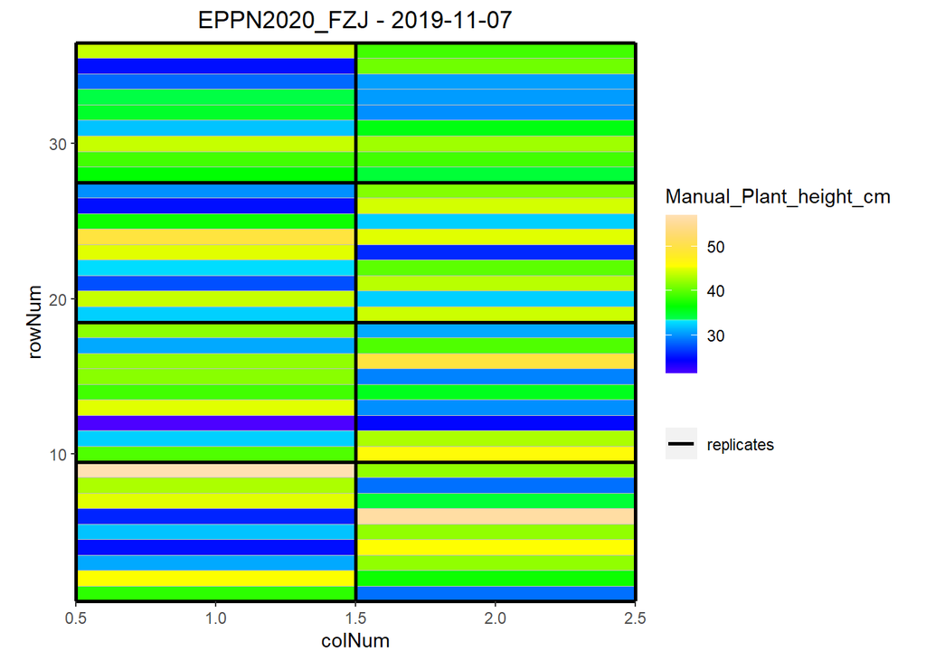

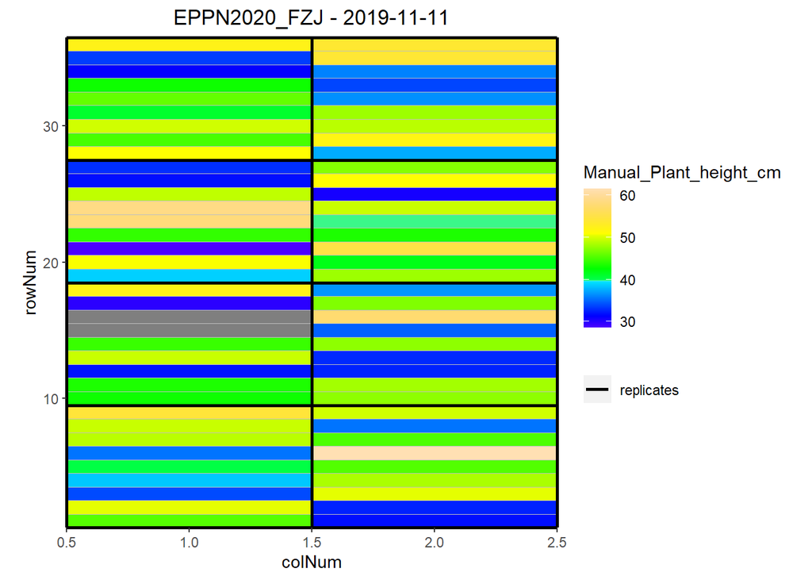

```r
for (trait_name in traits) {
  for (tp in 1:length(num_timepoints$timeNumber)) {
    plot(timePoint_S,
         plotType = "layout",
         timePoints = tp,
         traits = trait_name)
  }
}
```

#### Check time course of raw data per time point

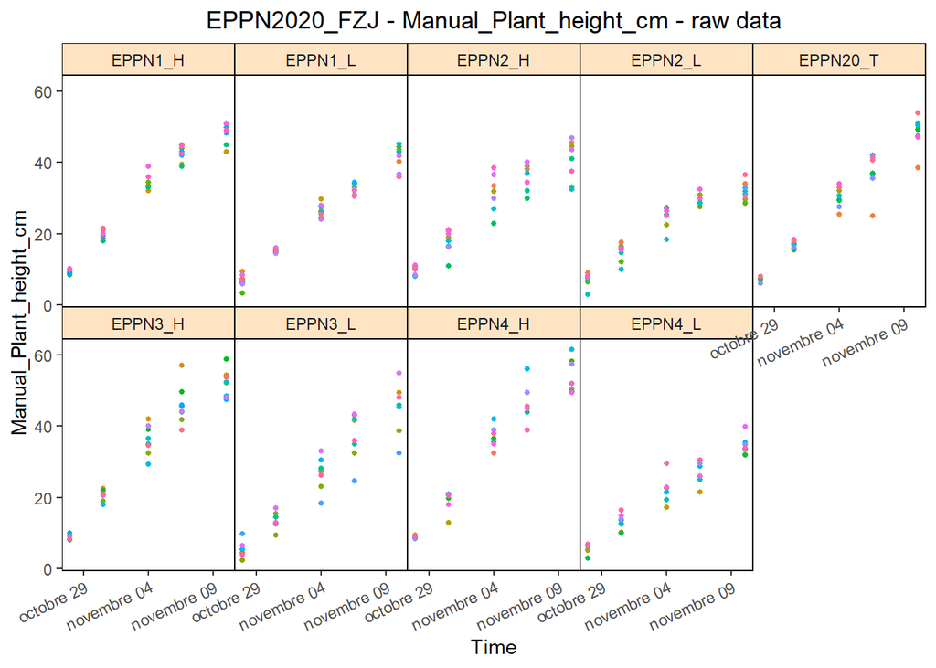

```r
for (trait_name in traits) {
  plot(timePoint_S,
     traits = trait_name,
     plotType = "raw")
}
```

#### Check the boxplots of raw data per time point

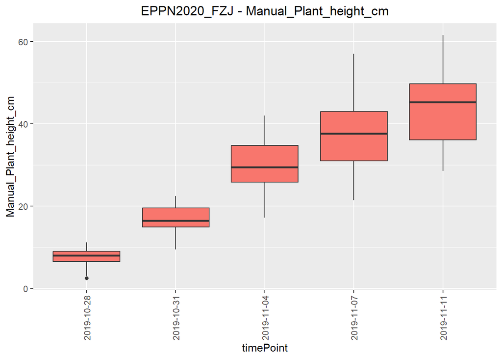

```r
for (trait_name in traits) {
  plot(timePoint_S,
     plotType = "box",
     traits = trait_name)
}
```

#### Check the correlation plots of raw data per time point

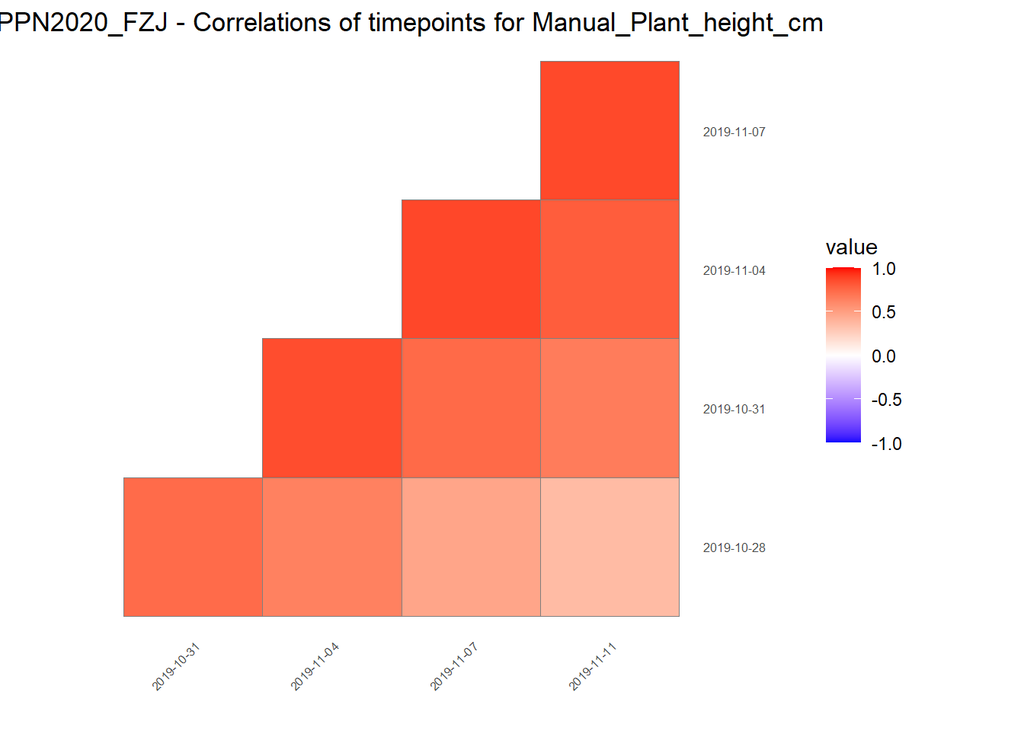

```r
for (trait_name in traits) {
  plot(timePoint_S,
     plotType = "cor",
     traits = trait_name)
}
```

### 1. Detection of outliers for single observations

Using the SingleOut detect and single functions. We select a subset of plants to adjust the settings for the confIntSize and nnLocfit.

```r
plantSel<- c(1,2,3,4,5,6,7,8,9,10)

ci <- 5 # confidence interval
nn <- 0.8 # nearest neighbor
ce <- FALSE
```

```r
#for (trait_name in traits) {
#  variable_name <- paste0("Single_test_", trait_name)
#
#  single_test <- detectSingleOut(
#    TP = timePoint_S,
#    trait = trait_name,
#    plotIds = plantSel,
#    confIntSize = ci,
#    nnLocfit = nn,
#    checkEdges = TRUE # check for outlier values in start and end of experiment
#  )

#  assign(variable_name, single_test)

#  plot(single_test, outOnly = FALSE)
#}

print("Erreur dans detectSingleOut(TP = timePoint_S, trait = trait_name, plotIds = plantSel,  :
  Not enough data points (<= 6) for any of the plots.")
```

```
## [1] "Erreur dans detectSingleOut(TP = timePoint_S, trait = trait_name, plotIds = plantSel,  : \n  Not enough data points (<= 6) for any of the plots."
```

#### Data visualisation after single observations outliers removal

##### Heatmap of data

Check the heatmap of the data with outliers detection at all the time points.

```r
for (trait_name in traits) {
  single_outliers_name <- paste0("Single_outliers_", trait_name)

  if (exists(single_outliers_name)) {
    Single_outliers <- get(single_outliers_name)

    for (tp in 1:length(num_timepoints$timeNumber)) {
      plot(Single_outliers,
           plotType = "layout",
           timePoints = tp,
           traits = trait_name)
    }
  } else {
    cat("No object Single_outliers found for trait", trait_name, "\n")
  }
}
```

```
## No object Single_outliers found for trait Manual_Plant_height_cm
```

##### Time course, boxplots and correlation plots of data

```r
for (trait_name in traits) {
  single_outliers_name <- paste0("Single_outliers_", trait_name)

  if (exists(single_outliers_name)) {
    Single_outliers <- get(single_outliers_name)

    plot(Single_outliers,
         traits = trait_name,
         plotType = "raw")

    plot(Single_outliers,
         plotType = "box",
         traits = trait_name)

    plot(Single_outliers,
         plotType = "cor",
         traits = trait_name)

  } else {
    cat("No Single_outliers object found for trait", trait_name, "\n")
  }
}
```

```
## No Single_outliers object found for trait Manual_Plant_height_cm
```

### 2. Correction for spatial trends

#### Model visualisation

```r
for (trait_name in traits) {
  mod_name <- paste0("modTP_", trait_name)

  if (exists(mod_name)) {
    mod <- get(mod_name)

    for (tp in 1:length(num_timepoints$timeNumber)) {
      plot(mod,
           timePoints = tp,
           plotType = "spatial",
           spaTrend = "percentage")
    }

    gif_file <- sprintf("%s/%s_mod.gif", datadir, trait_name)

    plot(mod,
         plotType = "timeLapse",
         spaTrend = "percentage",
         outFile = gif_file)
  } else {
    cat("No model found for", trait_name, "\n")
  }
}
```

```
## No model found for Manual_Plant_height_cm
```

```r
for (trait_name in traits) {
  mod_name <- paste0("modTP_", trait_name)
    if (exists(mod_name)) {
    mod <- get(mod_name)

    plot(mod,
         plotType = "rawPred",
         plotLine = TRUE)

    plot(mod,
         plotType = "corrPred",
         plotLine = TRUE)

    plot(mod,
         plotType = "herit",
         yLim = c(0, 0.5))

    plot(mod,
         plotType = "effDim",
         EDType = "ratio",
         yLim = c(0, 1))

    plot(mod,
         plotType = "corrPred")
  } else {
    cat("No model found for the trait", trait_name, "\n")
  }
}
```

```
## No model found for the trait Manual_Plant_height_cm
```

### 3. Outlier detection for series of observations

By using the splines.

#### fitModels

```r
for (trait_name in traits) {
  Spatial_Corrected_name <- paste0("Spatial_Corrected_", trait_name)
  modTP_name <- paste0("modTP_", trait_name)
}
```

```r
knots <- c(30)
mintimepoints <- c(9) # Minimal number of observations

for (trait_name in traits) {
  # Nom de la variable pour les données corrigées
  Spatial_Corrected_name <- paste0("Spatial_Corrected_", trait_name)
  modTP_name <- paste0("modTP_", trait_name)

  # Vérifier si le modèle existe
  if (exists(modTP_name)) {
    modTP <- get(modTP_name)
    Spatial_Corrected <- getCorrected(modTP)
    assign(Spatial_Corrected_name, Spatial_Corrected)

    # Ajuster les splines pour les données corrigées
    fit.spline <- fitSpline(inDat = Spatial_Corrected,
                            trait = paste0(trait_name, "_corr"),
                            knots = knots,
                            minNoTP = mintimepoints)

    # Extraire les tables de valeurs prédites et coefficients de splines
    predDat_name <- paste0("predDat_", trait_name)
    coefDat_name <- paste0("coefDat_", trait_name)

    assign(predDat_name, fit.spline$predDat)
    assign(coefDat_name, fit.spline$coefDat)
  } else {
    cat("No model found for", trait_name, "\n")
  }
}
```

```
## No model found for Manual_Plant_height_cm
```

#### detectSerieOut

```r
thrCor <- c(0.9) # correlation threshold
thrPca <- c(30) # pca angle threshold
thrSlope <- c(0.7) # slope threshold

for (trait_name in traits) {
  Spatial_Corrected_name <- paste0("Spatial_Corrected_", trait_name)
  predDat_name <- paste0("predDat_", trait_name)
  coefDat_name <- paste0("coefDat_", trait_name)

  if (exists(Spatial_Corrected_name) && exists(predDat_name) && exists(coefDat_name)) {
    Spatial_Corrected <- get(Spatial_Corrected_name)
    predDat <- get(predDat_name)
    coefDat <- get(coefDat_name)

    Series_test <- detectSerieOut(corrDat = Spatial_Corrected,
                                  predDat = predDat,
                                  coefDat = coefDat,
                                  trait = paste0(trait_name, "_corr"),
                                  thrCor = thrCor,
                                  thrPca = thrPca,
                                  thrSlope = thrSlope,
                                  geno.decomp = "geno.decomp")

    plot(Series_test, genotypes = levels(factor(Series_test$genotype)))

    assign(paste0("Series_test_", trait_name), Series_test)

    assign(paste0("Spatial_Corrected_Out_", trait_name), Spatial_Corrected)
  } else {
    cat("No corrected data or prediction data found for", trait_name, "\n")
  }
}
```

```
## No corrected data or prediction data found for Manual_Plant_height_cm
```

#### removeSerieOut

```r
for (trait_name in traits) {
  # Nom de la variable pour les données corrigées
  Spatial_Corrected_name <- paste0("Spatial_Corrected_", trait_name)
  Series_test_name <- paste0("Series_test_", trait_name)

  # Extraire les données corrigées et les résultats des séries
  if (exists(Spatial_Corrected_name) && exists(Series_test_name)) {
    Spatial_Corrected <- get(Spatial_Corrected_name)
    Series_test <- get(Series_test_name)

    # Supprimer les outliers de la série
    Spatial_Corrected_Out <- removeSerieOut(dat = Spatial_Corrected, serieOut = Series_test)

    # Assigner le résultat à une nouvelle variable
    assign(paste0("Spatial_Corrected_Out_", trait_name), Spatial_Corrected_Out)
  } else {
    cat("No corrected data or series test data found for", trait_name, "\n")
  }
}
```

```
## No corrected data or series test data found for Manual_Plant_height_cm
```

```r
for (trait_name in traits) {
  Spatial_Corrected_Out_name <- paste0("Spatial_Corrected_Out_", trait_name)

  if (exists(Spatial_Corrected_Out_name)) {
    Spatial_Corrected_Out <- get(Spatial_Corrected_Out_name)
    output_file <- sprintf("%s/timeSeriesOutliers_%s.tsv", datadir, trait_name)
    readr::write_tsv(Spatial_Corrected_Out, output_file)

    cat("Data written to:", output_file, "\n")
  } else {
    cat("No corrected data found for", trait_name, "\n")
  }
}
```

```
## No corrected data found for Manual_Plant_height_cm
```

### 4. With the cleaned data, re-do the spatial correction

This is used to compare the values before and after.

Need to write a for loop for all the variables.

#### Estimation of parameter from time series